# Abundance Analyses

From [SMAMMUNITY: SMall mAMMal commUNITY](https://github.com/katekathrynkat/smammunity)

**Kate Culhane**, Dept. of Ecology, Evolution, and Marine Biology, UC Santa Barbara  
kathrynculhane@ucsb.edu

**Publication:** Culhane, K., R. Sollmann, A.M. White, G.L. Tarbill, S. Cooper, M.A. Moritz, H.S. Young. (2021). Small mammal functional traits and vegetation characteristics mediate community responses to fire severity. Ecological Applications. Manuscript submitted for initial review.

**Source code:** 05_abundance.Rmd

## Total unique individuals per species

[output not shown]

- Although traps were primarily open at night, we can still include diurnal species (chipmunks, squirrels) in measures of relative abundance because traps were opened and closed at approximately the same time each day.
- Flying squirrels spend a significant amount of time foraging on the ground, so their capture was not a fluke.

## Ratio of recaptured animals

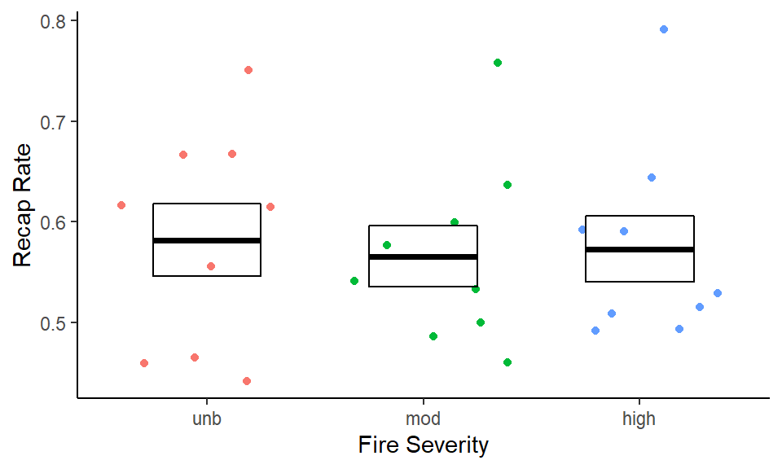

```
##
##  Kruskal-Wallis rank sum test
##
## data:  rate by severity
## Kruskal-Wallis chi-squared = 0.12975, df = 2, p-value = 0.9372
```

- Ratio of recaptures : total captures for each site
- Very similar between treatments (sort of all over the place, though)

## Proportional abundance

### By site

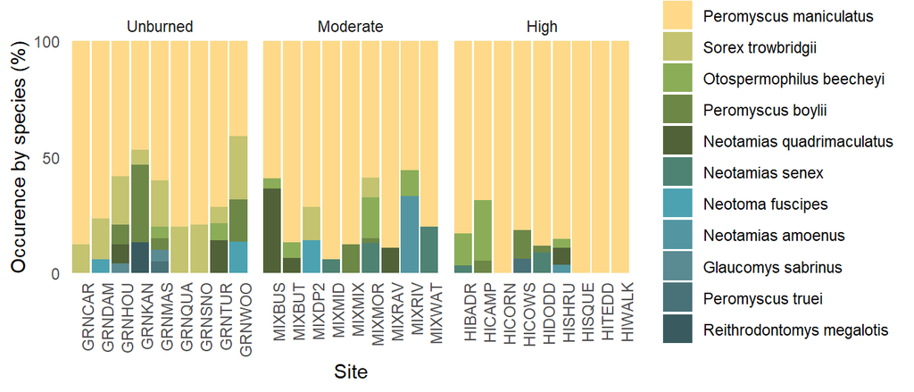

### By species

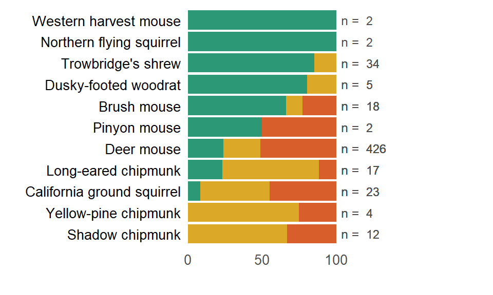

- Habitat preferences for the 11 species of mammals, standardized by trapping effort.

## Total abundance

### Abundance

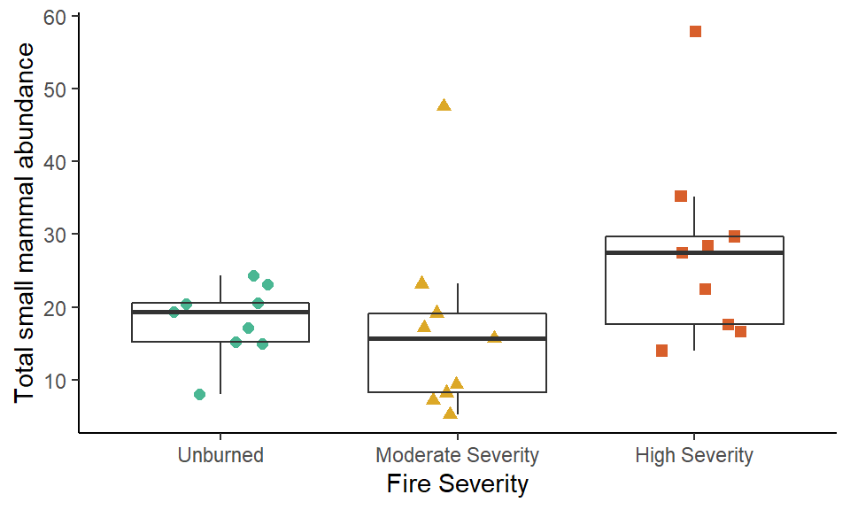

```
##
##  Kruskal-Wallis rank sum test
##
## data:  n_adj by severity
## Kruskal-Wallis chi-squared = 5.2628, df = 2, p-value = 0.07198
```

```
## # A tibble: 1 x 5
##   .y.       n effsize method  magnitude
## * <chr> <int>   <dbl> <chr>   <ord>
## 1 n_adj    27   0.136 eta2[H] moderate
```

### Biomass

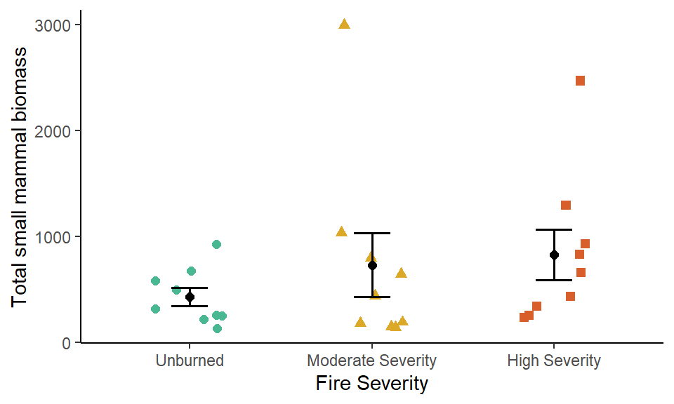

```
##
##  Kruskal-Wallis rank sum test
##
## data:  biomass by severity
## Kruskal-Wallis chi-squared = 2.1305, df = 2, p-value = 0.3446
```

```
## # A tibble: 1 x 5
##   .y.         n effsize method  magnitude
## * <chr>   <int>   <dbl> <chr>   <ord>
## 1 biomass    27 0.00544 eta2[H] small
```

## Abundance by species

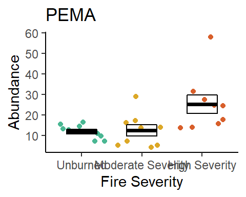

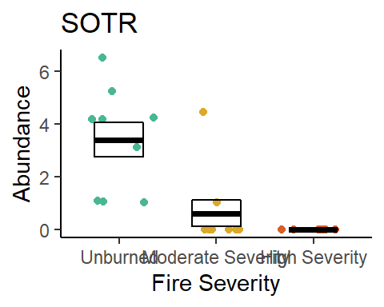

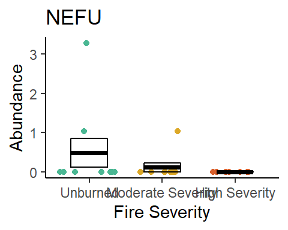

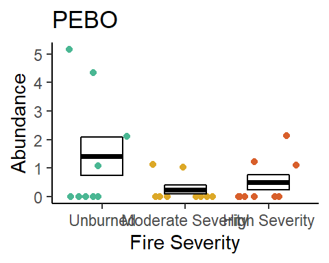

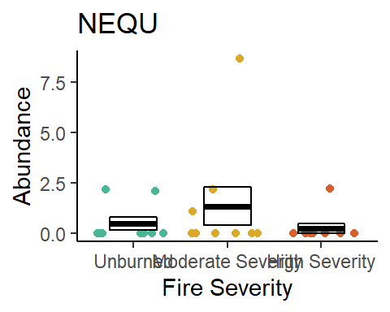

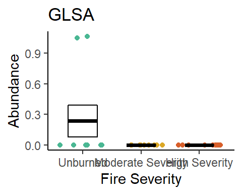

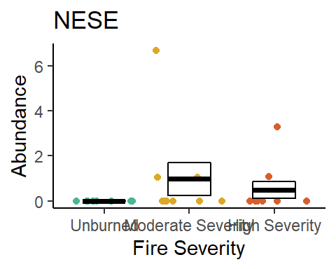

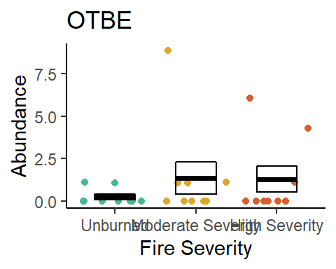

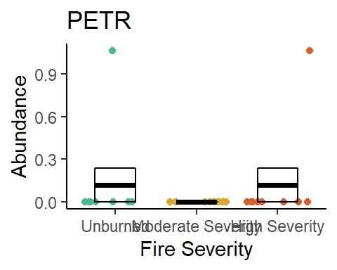

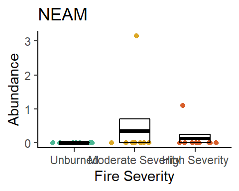

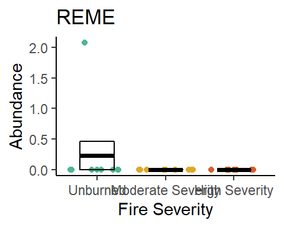

- Jitter plot points represent total small mammal abundance at each site; horizontal bars represent mean and standard error for each fire severity category.
- Abundance was standardized by trapping effort for each species individually (i.e. non-target species were counted as half of a trap night, similar to treatment of sprung traps).
- Two of these sites look like outliers:
  - HICORN had a ridiculous number of PEMA
  - MIXMOR had a lot of PEMA, OTBE, and SOTR

### Deer mouse (PEMA) abundance

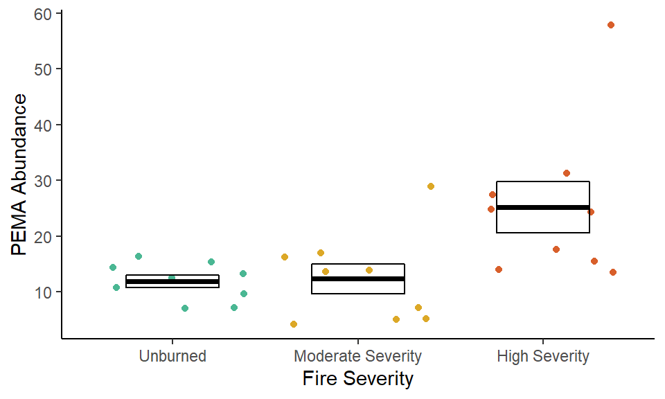

```
##   Kruskal-Wallis rank sum test
##
## data: x and group
## Kruskal-Wallis chi-squared = 9.2436, df = 2, p-value = 0.01
##
##
##                            Comparison of x by group
##                                  (Bonferroni)
## Col Mean-|
## Row Mean |       high        mod
## ---------+----------------------
##      mod |   2.539369
##          |    0.0167*
##      unb |   2.717570   0.178201
##          |    0.0099*     1.0000
##
## alpha = 0.05
## Reject Ho if p <= alpha/2
```

```
## # A tibble: 1 x 5
##   .y.            n effsize method  magnitude
## * <chr>      <int>   <dbl> <chr>   <ord>
## 1 n_adj_pema    27   0.302 eta2[H] large
```

- Jitter plot points represent PEMA abundance at each site; horizontal bars represent mean and standard error for each fire severity category. Abundance was standardized by trapping effort.
- Significant by K-W (p = 0.01, large eff size)

### Trowbridge’s shrew (SOTR) abundance

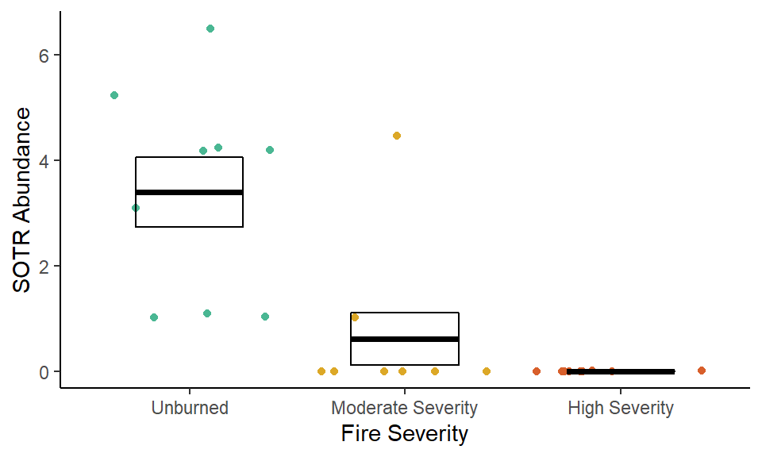

```
##   Kruskal-Wallis rank sum test
##
## data: x and group
## Kruskal-Wallis chi-squared = 18.543, df = 2, p-value = 0
##
##
##                            Comparison of x by group
##                                  (Bonferroni)
## Col Mean-|
## Row Mean |       high        mod
## ---------+----------------------
##      mod |  -0.867334
##          |     0.5786
##      unb |  -4.086477  -3.219143
##          |    0.0001*    0.0019*
##
## alpha = 0.05
## Reject Ho if p <= alpha/2
```

```
## # A tibble: 1 x 5
##   .y.            n effsize method  magnitude
## * <chr>      <int>   <dbl> <chr>   <ord>
## 1 n_adj_sotr    27   0.689 eta2[H] large
```

- Jitter plot points represent SOTR abundance at each site; horizontal bars represent mean and standard error for each fire severity category. Abundance was standardized by trapping effort.
- Significant by K-W (p < 0.001, large eff size)